# NIJ_Recidivism

Nicholas Hollman

2025-05-03

## Libraries used

```r
library(tidyverse)
library(psych)
library(summarytools)
library(gmodels)
```

```r
library(ggplot2)
```

## Import data

```r
NIJ <- read_csv("C:\\Users\\nickd\\OneDrive\\RProj\\NIJ_s_Recidivism_Challenge_Full_Dataset_20250503.csv", show_col_types = TRUE)
```

## Summary of initial import

```r
summary(NIJ)
```

```
##        ID           Gender              Race           Age_at_Release
##  Min.   :    1   Length:25835       Length:25835       Length:25835
##  1st Qu.: 6626   Class :character   Class :character   Class :character
##  Median :13270   Mode  :character   Mode  :character   Mode  :character
##  Mean   :13314
##  3rd Qu.:20022
##  Max.   :26761
##
##  Residence_PUMA  Gang_Affiliated Supervision_Risk_Score_First
##  Min.   : 1.00   Mode :logical   Min.   : 1.000
##  1st Qu.: 6.00   FALSE:18730     1st Qu.: 4.000
##  Median :12.00   TRUE :3938      Median : 6.000
##  Mean   :12.36   NA's :3167      Mean   : 6.082
##  3rd Qu.:18.00                   3rd Qu.: 8.000
##  Max.   :25.00                   Max.   :10.000
##                                  NA's   :475
##  Supervision_Level_First Education_Level     Dependents
##  Length:25835            Length:25835       Length:25835
##  Class :character        Class :character   Class :character
##  Mode  :character        Mode  :character   Mode  :character
##
##
##
##
##  Prison_Offense     Prison_Years       Prior_Arrest_Episodes_Felony
##  Length:25835       Length:25835       Length:25835
##  Class :character   Class :character   Class :character
##  Mode  :character   Mode  :character   Mode  :character
##
##
##
##
##  Prior_Arrest_Episodes_Misd Prior_Arrest_Episodes_Violent
##  Length:25835               Length:25835
##  Class :character           Class :character
##  Mode  :character           Mode  :character
##
##
##
##
```

[output cut: 113 more lines]

```
##  Mode :logical     Mode :logical            Mode :logical
##  FALSE:22399       FALSE:10931              FALSE:18111
##  TRUE :3436        TRUE :14904              TRUE :7724
##
##
##
##
##  Recidivism_Arrest_Year2 Recidivism_Arrest_Year3 Training_Sample
##  Mode :logical           Mode :logical           Min.   :0.0000
##  FALSE:21268             FALSE:23222             1st Qu.:0.0000
##  TRUE :4567              TRUE :2613              Median :1.0000
##                                                  Mean   :0.6978
##                                                  3rd Qu.:1.0000
##                                                  Max.   :1.0000
##
```

# Summary of missing data

```r
missing_counts <- colSums(is.na(NIJ))
```

```r
missing_percents <- colMeans(is.na(NIJ)) * 100
```

```r
missing_summary <- data.frame(
  column = names(missing_counts),
  missing_count = missing_counts,
  missing_percent = missing_percents
)
```

```r
missing_summary %>%
  arrange(desc(missing_percent))
```

```
##                                                                                              column
## Avg_Days_per_DrugTest                                                         Avg_Days_per_DrugTest
## DrugTests_THC_Positive                                                       DrugTests_THC_Positive
## DrugTests_Cocaine_Positive                                               DrugTests_Cocaine_Positive
## DrugTests_Meth_Positive                                                     DrugTests_Meth_Positive
## DrugTests_Other_Positive                                                   DrugTests_Other_Positive
## Prison_Offense                                                                       Prison_Offense
## Gang_Affiliated                                                                     Gang_Affiliated
## Supervision_Level_First                                                     Supervision_Level_First
## Jobs_Per_Year                                                                         Jobs_Per_Year
## Supervision_Risk_Score_First                                           Supervision_Risk_Score_First
## Percent_Days_Employed                                                         Percent_Days_Employed
## ID                                                                                               ID
## Gender                                                                                       Gender
## Race                                                                                           Race
## Age_at_Release                                                                       Age_at_Release
## Residence_PUMA                                                                       Residence_PUMA
## Education_Level                                                                     Education_Level
## Dependents                                                                               Dependents
## Prison_Years                                                                           Prison_Years
## Prior_Arrest_Episodes_Felony                                           Prior_Arrest_Episodes_Felony
## Prior_Arrest_Episodes_Misd                                               Prior_Arrest_Episodes_Misd
## Prior_Arrest_Episodes_Violent                                         Prior_Arrest_Episodes_Violent
## Prior_Arrest_Episodes_Property                                       Prior_Arrest_Episodes_Property
## Prior_Arrest_Episodes_Drug                                               Prior_Arrest_Episodes_Drug
## Prior_Arrest_Episodes_PPViolationCharges                   Prior_Arrest_Episodes_PPViolationCharges
## Prior_Arrest_Episodes_DVCharges                                     Prior_Arrest_Episodes_DVCharges
## Prior_Arrest_Episodes_GunCharges                                   Prior_Arrest_Episodes_GunCharges
## Prior_Conviction_Episodes_Felony                                   Prior_Conviction_Episodes_Felony
## Prior_Conviction_Episodes_Misd                                       Prior_Conviction_Episodes_Misd
## Prior_Conviction_Episodes_Viol                                       Prior_Conviction_Episodes_Viol
## Prior_Conviction_Episodes_Prop                                       Prior_Conviction_Episodes_Prop
## Prior_Conviction_Episodes_Drug                                       Prior_Conviction_Episodes_Drug
## Prior_Conviction_Episodes_PPViolationCharges           Prior_Conviction_Episodes_PPViolationCharges
## Prior_Conviction_Episodes_DomesticViolenceCharges Prior_Conviction_Episodes_DomesticViolenceCharges
## Prior_Conviction_Episodes_GunCharges                           Prior_Conviction_Episodes_GunCharges
## Prior_Revocations_Parole                                                   Prior_Revocations_Parole
## Prior_Revocations_Probation                                             Prior_Revocations_Probation
## Condition_MH_SA                                                                     Condition_MH_SA
## Condition_Cog_Ed                                                                   Condition_Cog_Ed
```

[output cut: 55 more lines]

```
## Condition_Other                                               0        0.000000
## Violations_ElectronicMonitoring                               0        0.000000
## Violations_Instruction                                        0        0.000000
## Violations_FailToReport                                       0        0.000000
## Violations_MoveWithoutPermission                              0        0.000000
## Delinquency_Reports                                           0        0.000000
## Program_Attendances                                           0        0.000000
## Program_UnexcusedAbsences                                     0        0.000000
## Residence_Changes                                             0        0.000000
## Employment_Exempt                                             0        0.000000
## Recidivism_Within_3years                                      0        0.000000
## Recidivism_Arrest_Year1                                       0        0.000000
## Recidivism_Arrest_Year2                                       0        0.000000
## Recidivism_Arrest_Year3                                       0        0.000000
## Training_Sample                                               0        0.000000
```

#Several variables in the dataset had more than 20% missing data. For the purposes of this portfolio project, listwise deletion was applied to simplify the analysis and ensure complete cases. However, in a real-world setting, I would collaborate with stakeholders and domain experts to assess the nature of the missingness and determine an appropriate imputation strategy based on analytic goals and the importance of each variable. Depending on the context, potential methods might include mean or median imputation for continuous variables, mode imputation for categorical variables, or more advanced techniques such as multiple imputation or predictive modeling.

```r
NIJ_clean <- NIJ %>% drop_na()
```

```r
missing_counts_clean <- colSums(is.na(NIJ_clean))
print(missing_counts_clean)
```

```
##                                                ID
##                                                 0
##                                            Gender
##                                                 0
##                                              Race
##                                                 0
##                                    Age_at_Release
##                                                 0
##                                    Residence_PUMA
##                                                 0
##                                   Gang_Affiliated
##                                                 0
##                      Supervision_Risk_Score_First
##                                                 0
##                           Supervision_Level_First
##                                                 0
##                                   Education_Level
##                                                 0
##                                        Dependents
##                                                 0
##                                    Prison_Offense
##                                                 0
##                                      Prison_Years
##                                                 0
##                      Prior_Arrest_Episodes_Felony
##                                                 0
##                        Prior_Arrest_Episodes_Misd
##                                                 0
##                     Prior_Arrest_Episodes_Violent
##                                                 0
##                    Prior_Arrest_Episodes_Property
##                                                 0
##                        Prior_Arrest_Episodes_Drug
##                                                 0
##          Prior_Arrest_Episodes_PPViolationCharges
##                                                 0
##                   Prior_Arrest_Episodes_DVCharges
##                                                 0
##                  Prior_Arrest_Episodes_GunCharges
##                                                 0
```

[output cut: 53 more lines]

```
##                                                 0
##                                     Jobs_Per_Year
##                                                 0
##                                 Employment_Exempt
##                                                 0
##                          Recidivism_Within_3years
##                                                 0
##                           Recidivism_Arrest_Year1
##                                                 0
##                           Recidivism_Arrest_Year2
##                                                 0
##                           Recidivism_Arrest_Year3
##                                                 0
##                                   Training_Sample
##                                                 0
```

```r
# drop other recidivism columns as these are all captured with our outcome of interest
library(dplyr)
NIJ_clean <- NIJ_clean %>% select(-Recidivism_Arrest_Year1, -Recidivism_Arrest_Year2, -Recidivism_Arrest_Year3)
names(NIJ_clean)
```

```
##  [1] "ID"
##  [2] "Gender"
##  [3] "Race"
##  [4] "Age_at_Release"
##  [5] "Residence_PUMA"
##  [6] "Gang_Affiliated"
##  [7] "Supervision_Risk_Score_First"
##  [8] "Supervision_Level_First"
##  [9] "Education_Level"
## [10] "Dependents"
## [11] "Prison_Offense"
## [12] "Prison_Years"
## [13] "Prior_Arrest_Episodes_Felony"
## [14] "Prior_Arrest_Episodes_Misd"
## [15] "Prior_Arrest_Episodes_Violent"
```

[output cut: 36 more lines]

```r
NIJ_clean$Recidivism_Within_3years <- as.numeric(NIJ_clean$Recidivism_Within_3years)
set.seed(123)
library(caret)
split <- createDataPartition(NIJ_clean$Recidivism_Within_3years, p = 0.7, list = FALSE)
train_data <- NIJ_clean[split, ]
test_data  <- NIJ_clean[-split, ]
dfSummary(train_data)
```

```
## Data Frame Summary
## train_data
## Dimensions: 9919 x 51
## Duplicates: 0
##
## ----------------------------------------------------------------------------------------------------------------------------------------------------------
## No   Variable                                            Stats / Values                 Freqs (% of Valid)     Graph                  Valid      Missing
## ---- --------------------------------------------------- ------------------------------ ---------------------- ---------------------- ---------- ---------
## 1    ID                                                  Mean (sd) : 13080.3 (7493)     9919 distinct values   . . . : . : : .        9919       0
##      [numeric]                                           min < med < max:                                      : : : : : : : : : .    (100.0%)   (0.0%)
##                                                          1 < 13132 < 26734                                     : : : : : : : : : :
##                                                          IQR (CV) : 12710 (0.6)                                : : : : : : : : : :
##                                                                                                                : : : : : : : : : :
##
## 2    Gender                                              1. M                           9919 (100.0%)          IIIIIIIIIIIIIIIIIIII   9919       0
##      [character]                                                                                                                      (100.0%)   (0.0%)
##
## 3    Race                                                1. BLACK                       5869 (59.2%)           IIIIIIIIIII            9919       0
##      [character]                                         2. WHITE                       4050 (40.8%)           IIIIIIII               (100.0%)   (0.0%)
##
## 4    Age_at_Release                                      1. 18-22                        926 ( 9.3%)           I                      9919       0
##      [character]                                         2. 23-27                       2232 (22.5%)           IIII                   (100.0%)   (0.0%)
##                                                          3. 28-32                       1928 (19.4%)           III
##                                                          4. 33-37                       1577 (15.9%)           III
##                                                          5. 38-42                       1034 (10.4%)           II
##                                                          6. 43-47                        932 ( 9.4%)           I
##                                                          7. 48 or older                 1290 (13.0%)           II
##
## 5    Residence_PUMA                                      Mean (sd) : 12.3 (7.1)         25 distinct values     .   :         .        9919       0
##      [numeric]                                           min < med < max:                                      : : :   .   . :        (100.0%)   (0.0%)
##                                                          1 < 12 < 25                                           : : :   : : : : . :
##                                                          IQR (CV) : 12 (0.6)                                   : : : : : : : : : :
##                                                                                                                : : : : : : : : : :
##
## 6    Gang_Affiliated                                     1. FALSE                       8059 (81.2%)           IIIIIIIIIIIIIIII       9919       0
##      [logical]                                           2. TRUE                        1860 (18.8%)           III                    (100.0%)   (0.0%)
##
## 7    Supervision_Risk_Score_First                        Mean (sd) : 6.4 (2.3)          1 :  168 ( 1.7%)                              9919       0
##      [numeric]                                           min < med < max:               2 :  368 ( 3.7%)                              (100.0%)   (0.0%)
##                                                          1 < 6 < 10                     3 :  716 ( 7.2%)       I
```

[output cut: 209 more lines]

```
##                                                          0 < 0.7 < 8                                           : .
##                                                          IQR (CV) : 1 (1)                                      : :
##                                                                                                                : : : .
##
## 49   Employment_Exempt                                   1. FALSE                       8694 (87.6%)           IIIIIIIIIIIIIIIII      9919       0
##      [logical]                                           2. TRUE                        1225 (12.4%)           II                     (100.0%)   (0.0%)
##
## 50   Recidivism_Within_3years                            Min  : 0                       0 : 4027 (40.6%)       IIIIIIII               9919       0
##      [numeric]                                           Mean : 0.6                     1 : 5892 (59.4%)       IIIIIIIIIII            (100.0%)   (0.0%)
##                                                          Max  : 1
##
## 51   Training_Sample                                     Min  : 0                       0 : 3015 (30.4%)       IIIIII                 9919       0
##      [numeric]                                           Mean : 0.7                     1 : 6904 (69.6%)       IIIIIIIIIIIII          (100.0%)   (0.0%)
##                                                          Max  : 1
## ----------------------------------------------------------------------------------------------------------------------------------------------------------
```

```r
# out of below output, Recidivism_Within_3years, ID, and training sample
train_data %>%
  group_by(Recidivism_Within_3years) %>%
  summarise(across(where(is.numeric), list(mean = mean, sd = sd), na.rm = TRUE))
```

```
## # A tibble: 2 × 23
##   Recidivism_Within_3years ID_mean ID_sd Residence_PUMA_mean Residence_PUMA_sd
##                      <dbl>   <dbl> <dbl>               <dbl>             <dbl>
## 1                        0  13121. 7625.                12.0              7.10
## 2                        1  13052. 7402.                12.5              7.14
## # ℹ 18 more variables: Supervision_Risk_Score_First_mean <dbl>,
## #   Supervision_Risk_Score_First_sd <dbl>, Avg_Days_per_DrugTest_mean <dbl>,
## #   Avg_Days_per_DrugTest_sd <dbl>, DrugTests_THC_Positive_mean <dbl>,
## #   DrugTests_THC_Positive_sd <dbl>, DrugTests_Cocaine_Positive_mean <dbl>,
## #   DrugTests_Cocaine_Positive_sd <dbl>, DrugTests_Meth_Positive_mean <dbl>,
## #   DrugTests_Meth_Positive_sd <dbl>, DrugTests_Other_Positive_mean <dbl>,
## #   DrugTests_Other_Positive_sd <dbl>, Percent_Days_Employed_mean <dbl>, …
```

```r
dfSummary(train_data %>% select(Recidivism_Within_3years, where(is.factor), where(is.character)))
```

```
## Data Frame Summary
## Dimensions: 9919 x 23
## Duplicates: 2
##
## -----------------------------------------------------------------------------------------------------------------------------------------------
## No   Variable                                   Stats / Values                 Freqs (% of Valid)   Graph                  Valid      Missing
## ---- ------------------------------------------ ------------------------------ -------------------- ---------------------- ---------- ---------
## 1    Recidivism_Within_3years                   Min  : 0                       0 : 4027 (40.6%)     IIIIIIII               9919       0
##      [numeric]                                  Mean : 0.6                     1 : 5892 (59.4%)     IIIIIIIIIII            (100.0%)   (0.0%)
##                                                 Max  : 1
##
## 2    Gender                                     1. M                           9919 (100.0%)        IIIIIIIIIIIIIIIIIIII   9919       0
##      [character]                                                                                                           (100.0%)   (0.0%)
##
## 3    Race                                       1. BLACK                       5869 (59.2%)         IIIIIIIIIII            9919       0
##      [character]                                2. WHITE                       4050 (40.8%)         IIIIIIII               (100.0%)   (0.0%)
##
## 4    Age_at_Release                             1. 18-22                        926 ( 9.3%)         I                      9919       0
##      [character]                                2. 23-27                       2232 (22.5%)         IIII                   (100.0%)   (0.0%)
##                                                 3. 28-32                       1928 (19.4%)         III
##                                                 4. 33-37                       1577 (15.9%)         III
##                                                 5. 38-42                       1034 (10.4%)         II
##                                                 6. 43-47                        932 ( 9.4%)         I
##                                                 7. 48 or older                 1290 (13.0%)         II
##
## 5    Supervision_Level_First                    1. High                        2831 (28.5%)         IIIII                  9919       0
##      [character]                                2. Specialized                 3548 (35.8%)         IIIIIII                (100.0%)   (0.0%)
##                                                 3. Standard                    3540 (35.7%)         IIIIIII
##
## 6    Education_Level                            1. At least some college       1546 (15.6%)         III                    9919       0
##      [character]                                2. High School Diploma         4441 (44.8%)         IIIIIIII               (100.0%)   (0.0%)
##                                                 3. Less than HS diploma        3932 (39.6%)         IIIIIII
##
## 7    Dependents                                 1. 0                           3219 (32.5%)         IIIIII                 9919       0
##      [character]                                2. 1                           2125 (21.4%)         IIII                   (100.0%)   (0.0%)
##                                                 3. 2                           1696 (17.1%)         III
##                                                 4. 3 or more                   2879 (29.0%)         IIIII
##
## 8    Prison_Offense                             1. Drug                        2084 (21.0%)         IIII                   9919       0
##      [character]                                2. Other                       1301 (13.1%)         II                     (100.0%)   (0.0%)
```

[output cut: 88 more lines]

```
##                                                 8. 6                           1243 (12.5%)         II
##                                                 9. 7                            365 ( 3.7%)
##                                                 10. 8                           201 ( 2.0%)
##                                                 11. 9                           192 ( 1.9%)
##
## 22   Program_UnexcusedAbsences                  1. 0                           7532 (75.9%)         IIIIIIIIIIIIIII        9919       0
##      [character]                                2. 1                            777 ( 7.8%)         I                      (100.0%)   (0.0%)
##                                                 3. 2                            553 ( 5.6%)         I
##                                                 4. 3 or more                   1057 (10.7%)         II
##
## 23   Residence_Changes                          1. 0                           4955 (50.0%)         IIIIIIIII              9919       0
##      [character]                                2. 1                           2413 (24.3%)         IIII                   (100.0%)   (0.0%)
##                                                 3. 2                           1327 (13.4%)         II
##                                                 4. 3 or more                   1224 (12.3%)         II
## -----------------------------------------------------------------------------------------------------------------------------------------------
```

```r
drop_cols <- grep("Recidivism_Arrest_Year", names(train_data), value = TRUE)
train_data <- train_data %>% select(-all_of(drop_cols))
test_data <- test_data %>% select(names(train_data))  # ensure matching structure
# initially had error in below confirmed by summary statistics above, that some variables only have one level - dropping varaibles with only 1 level
# Remove predictors with only one unique value
train_data <- train_data %>% select(where(~ n_distinct(.) > 1))
test_data <- test_data %>% select(names(train_data))  # keep same vars as training
```

# Import libraries needed for predictive modeling

```r
library(caret)
library(glmnet)
library(pROC)
library(broom)
```

# Prepare data for LASSO

```r
# Ensure Recidivism_Arrest_Year1-3 are dropped before modeling (in case they reappeared)
drop_cols <- grep("Recidivism_Arrest_Year", names(train_data), value = TRUE)
train_data <- train_data %>% select(-all_of(drop_cols))
test_data <- test_data %>% select(names(train_data))  # ensure same structure
train_data <- train_data %>% select(-Training_Sample, -ID)
test_data  <- test_data %>% select(-Training_Sample, -ID)

x_train <- model.matrix(Recidivism_Within_3years ~ ., data = train_data)[, -1]
y_train <- train_data$Recidivism_Within_3years

x_test  <- model.matrix(Recidivism_Within_3years ~ ., data = test_data)[, -1]
y_test  <- test_data$Recidivism_Within_3years
```

# Cross-Validated LASSO Model

# alpha = 1 = use LASSO penalty (vs. alpha = 0 for Ridge, or between 0–1 for Elastic Net).

# nfolds = 5 = use 5-fold cross-validation (splits training data into 5 parts to evaluate performance).

```r
set.seed(123)
```

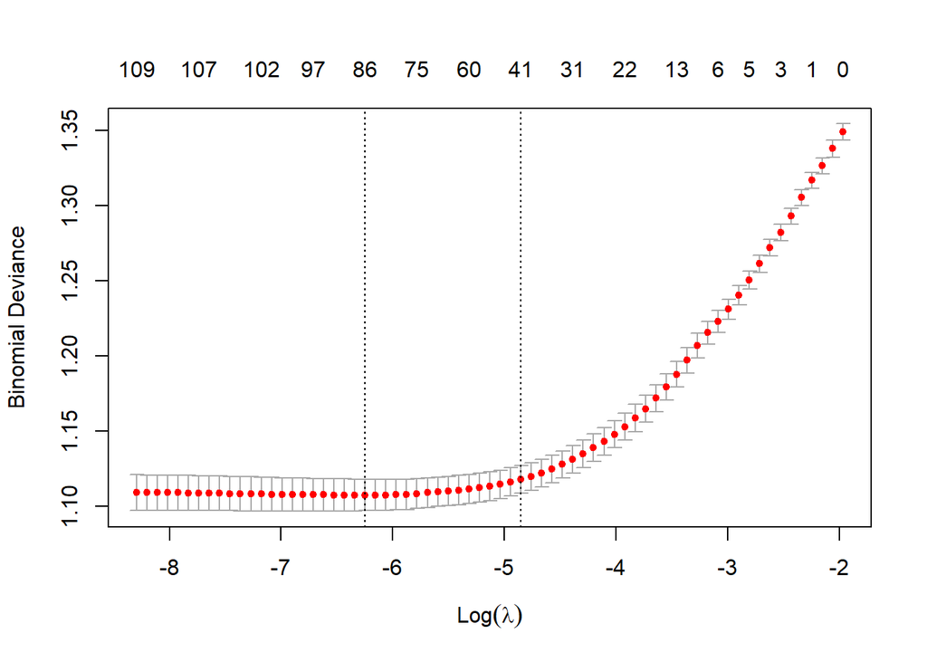

```r
cv_fit <- cv.glmnet(x_train, y_train, family = "binomial", alpha = 1, nfolds = 5)
plot(cv_fit) # Plots the cross-validated deviance (loss) for each lambda. Vertical dashed lines: One for lambda.min (lambda with lowest error).One for lambda.1se (more regularized but within 1 standard error of the best). This helps visually pick a trade-off between model complexity and performance.
```

```r
best_lambda <- cv_fit$lambda.min
print(best_lambda)# Extracts the best lambda value (i.e., the one that minimizes cross-validation error). This value will be used to predict and interpret the final model.
```

```
## [1] 0.001934879
```

## LASSO Coefficients

```r
lasso_coef <- coef(cv_fit, s = "lambda.min") # This line extracts the model coefficients at the optimal lambda value
lasso_coef_df <- as.data.frame(as.matrix(lasso_coef)) %>% #Converts the sparse matrix of coefficients into a regular data frame.
  rownames_to_column("feature") %>% # Adds the row names (which are the variable names, including the intercept) as a column called "feature".
  mutate(coefficient = .[[1]]) %>% # Creates a new column called coefficient from the first (and only) column of the data frame.
                                    # This is done because the original column had a non-descriptive name like s1.
  filter(coefficient != 0)   # Filters the data to keep only non-zero coefficients.
lasso_coef_df
```

```
##                                                   feature            s1
## 1                                             (Intercept) -0.2097483794
## 2                                               RaceWHITE  0.1175850966
## 3                                     Age_at_Release23-27  0.0000000000
## 4                                     Age_at_Release28-32 -0.1768436784
## 5                                     Age_at_Release33-37 -0.3590941995
## 6                                     Age_at_Release38-42 -0.5740220085
## 7                                     Age_at_Release43-47 -0.7031271585
## 8                               Age_at_Release48 or older -0.8523049181
## 9                                          Residence_PUMA  0.0095426919
## 10                                    Gang_AffiliatedTRUE  0.7550046930
## 11                           Supervision_Risk_Score_First  0.0790315216
## 12                     Supervision_Level_FirstSpecialized  0.0000000000
## 13                        Supervision_Level_FirstStandard -0.0802904489
## 14                     Education_LevelHigh School Diploma  0.1404199596
```

[output cut: 215 more lines]

```r
pred_probs <- predict(cv_fit, newx = x_test, s = "lambda.min", type = "response")
pred_class <- ifelse(pred_probs > 0.5, 1, 0)
confusionMatrix(factor(pred_class), factor(y_test), positive = "1")
```

```
## Confusion Matrix and Statistics
##
##           Reference
## Prediction    0    1
##          0 1008  478
##          1  712 2053
##
##                Accuracy : 0.7201
##                  95% CI : (0.7063, 0.7335)
##     No Information Rate : 0.5954
##     P-Value [Acc > NIR] : < 2.2e-16
##
##                   Kappa : 0.406
##
##  Mcnemar's Test P-Value : 1.435e-11
##
##             Sensitivity : 0.8111
##             Specificity : 0.5860
##          Pos Pred Value : 0.7425
##          Neg Pred Value : 0.6783
##              Prevalence : 0.5954
##          Detection Rate : 0.4829
##    Detection Prevalence : 0.6504
##       Balanced Accuracy : 0.6986
##
##        'Positive' Class : 1
##
```

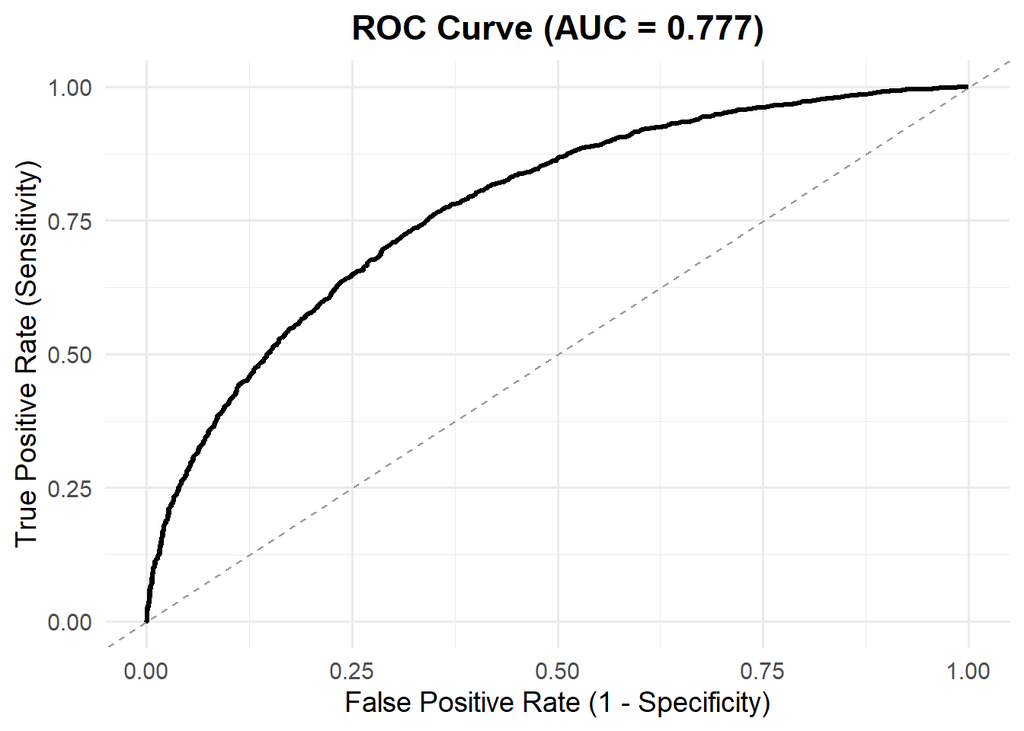

```r
library(pROC)
library(ggplot2)

# Create ROC object
roc_obj <- roc(y_test, as.vector(pred_probs), quiet = TRUE)

# Create ROC plot with correct axis and diagonal
ggplot(data = data.frame(
  tpr = roc_obj$sensitivities,
  fpr = 1 - roc_obj$specificities
)) +
  geom_line(aes(x = fpr, y = tpr), color = "black", size = 1.2) +
  geom_abline(slope = 1, intercept = 0, linetype = "dashed", color = "gray60") +
  labs(
    title = paste0("ROC Curve (AUC = ", round(auc(roc_obj), 3), ")"),
    x = "False Positive Rate (1 - Specificity)",
    y = "True Positive Rate (Sensitivity)"
  ) +
  theme_minimal(base_size = 14) +
  theme(
    plot.title = element_text(hjust = 0.5, face = "bold")
  )
```

## Refit Logistic Regression on Selected Variables

```r
# Drop ID and Training_Sample if they exist
train_data_model <- train_data %>%
  select(-any_of(c("ID", "Training_Sample")))

x_train <- model.matrix(Recidivism_Within_3years ~ ., data = train_data_model)[, -1]
y_train <- train_data_model$Recidivism_Within_3years

selected_vars <- rownames(lasso_coef)[lasso_coef[, 1] != 0]
selected_vars <- selected_vars[selected_vars != "(Intercept)"]

x_refit <- x_train[, selected_vars]

model_refit <- glm(y_train ~ ., data = as.data.frame(x_refit), family = binomial)

summary(model_refit)
```

```
##
## Call:
## glm(formula = y_train ~ ., family = binomial, data = as.data.frame(x_refit))
##
## Coefficients:
##                                                       Estimate Std. Error
## (Intercept)                                         -0.2866050  0.1815193
## RaceWHITE                                            0.1580825  0.0550836
## `Age_at_Release28-32`                               -0.3060758  0.0742939
## `Age_at_Release33-37`                               -0.5205288  0.0842030
## `Age_at_Release38-42`                               -0.7599768  0.1000275
## `Age_at_Release43-47`                               -0.9082707  0.1082038
## `Age_at_Release48 or older`                         -1.0562065  0.1098920
## Residence_PUMA                                       0.0111119  0.0033877
## Gang_AffiliatedTRUE                                  0.7735995  0.0713803
## Supervision_Risk_Score_First                         0.0710346  0.0146432
## Supervision_Level_FirstStandard                     -0.0938990  0.0595801
## `Education_LevelHigh School Diploma`                 0.1575668  0.0479679
## Dependents1                                          0.0381558  0.0598726
## Dependents2                                          0.0565353  0.0651818
## Prison_OffenseOther                                  0.0913630  0.0855073
## Prison_OffenseProperty                               0.1359511  0.0747227
## `Prison_OffenseViolent/Non-Sex`                      0.1533632  0.0835241
## `Prison_OffenseViolent/Sex`                         -0.0059494  0.1407070
## `Prison_YearsGreater than 2 to 3 years`             -0.1109911  0.0701430
## `Prison_YearsLess than 1 year`                       0.2497638  0.0704825
## `Prison_YearsMore than 3 years`                     -0.0297555  0.0713786
## Prior_Arrest_Episodes_Felony1                       -0.7142367  0.1048025
## `Prior_Arrest_Episodes_Felony10 or more`             0.4191104  0.1104036
## Prior_Arrest_Episodes_Felony2                       -0.2362783  0.0925762
## Prior_Arrest_Episodes_Felony3                       -0.0497765  0.0878304
## Prior_Arrest_Episodes_Felony6                        0.1050617  0.0985922
## Prior_Arrest_Episodes_Felony7                       -0.0990684  0.1040813
## Prior_Arrest_Episodes_Felony8                        0.1155033  0.1203647
## Prior_Arrest_Episodes_Felony9                        0.1264030  0.1304003
## Prior_Arrest_Episodes_Misd1                          0.1910224  0.0783413
## Prior_Arrest_Episodes_Misd2                          0.1379907  0.0835118
## Prior_Arrest_Episodes_Misd4                          0.3065007  0.0984707
## Prior_Arrest_Episodes_Misd5                          0.2144309  0.1067180
## `Prior_Arrest_Episodes_Misd6 or more`                0.3948971  0.0944325
```

[output cut: 136 more lines]

```
## DrugTests_Meth_Positive                               4.679 2.88e-06 ***
## DrugTests_Other_Positive                              1.404 0.160294
## Percent_Days_Employed                               -25.962  < 2e-16 ***
## Jobs_Per_Year                                        12.700  < 2e-16 ***
## Employment_ExemptTRUE                                -1.660 0.096952 .
## ---
## Signif. codes:  0 '***' 0.001 '**' 0.01 '*' 0.05 '.' 0.1 ' ' 1
##
## (Dispersion parameter for binomial family taken to be 1)
##
##     Null deviance: 13398  on 9918  degrees of freedom
## Residual deviance: 10754  on 9832  degrees of freedom
## AIC: 10928
##
## Number of Fisher Scoring iterations: 5
```

```r
exp_coef <- exp(coef(model_refit))
conf_int <- exp(confint(model_refit))
odds_table <- cbind(OR = exp_coef, conf_int)
colnames(odds_table) <- c("Odds Ratio", "2.5 %", "97.5 %")
odds_table
```

```
##                                                     Odds Ratio     2.5 %
## (Intercept)                                          0.7508083 0.5260055
## RaceWHITE                                            1.1712628 1.0514870
## `Age_at_Release28-32`                                0.7363308 0.6365369
## `Age_at_Release33-37`                                0.5942062 0.5037598
## `Age_at_Release38-42`                                0.4676773 0.3843231
## `Age_at_Release43-47`                                0.4032209 0.3260413
## `Age_at_Release48 or older`                          0.3477726 0.2802431
## Residence_PUMA                                       1.0111739 1.0044863
## Gang_AffiliatedTRUE                                  2.1675544 1.8860049
## Supervision_Risk_Score_First                         1.0736184 1.0432497
## Supervision_Level_FirstStandard                      0.9103747 0.8101142
## `Education_LevelHigh School Diploma`                 1.1706589 1.0656664
## Dependents1                                          1.0388931 0.9239872
## Dependents2                                          1.0581640 0.9314319
## Prison_OffenseOther                                  1.0956666 0.9267446
## Prison_OffenseProperty                               1.1456258 0.9894855
## `Prison_OffenseViolent/Non-Sex`                      1.1657483 0.9897614
## `Prison_OffenseViolent/Sex`                          0.9940682 0.7539455
## `Prison_YearsGreater than 2 to 3 years`              0.8949467 0.7800173
## `Prison_YearsLess than 1 year`                       1.2837221 1.1181895
## `Prison_YearsMore than 3 years`                      0.9706828 0.8439923
## Prior_Arrest_Episodes_Felony1                        0.4895657 0.3984291
## `Prior_Arrest_Episodes_Felony10 or more`             1.5206082 1.2250058
## Prior_Arrest_Episodes_Felony2                        0.7895609 0.6585032
## Prior_Arrest_Episodes_Felony3                        0.9514420 0.8010356
## Prior_Arrest_Episodes_Felony6                        1.1107791 0.9160342
## Prior_Arrest_Episodes_Felony7                        0.9056808 0.7387453
## Prior_Arrest_Episodes_Felony8                        1.1224382 0.8872388
## Prior_Arrest_Episodes_Felony9                        1.1347394 0.8795373
## Prior_Arrest_Episodes_Misd1                          1.2104866 1.0382757
## Prior_Arrest_Episodes_Misd2                          1.1479649 0.9747466
## Prior_Arrest_Episodes_Misd4                          1.3586624 1.1206256
## Prior_Arrest_Episodes_Misd5                          1.2391565 1.0056982
## `Prior_Arrest_Episodes_Misd6 or more`                1.4842314 1.2335728
## `Prior_Arrest_Episodes_Violent3 or more`             1.0173864 0.8725381
## Prior_Arrest_Episodes_Property1                      1.0378952 0.9175444
## Prior_Arrest_Episodes_Property4                      1.0511724 0.8650133
## `Prior_Arrest_Episodes_Property5 or more`            1.3059338 1.0966538
## Prior_Arrest_Episodes_Drug1                          0.9026703 0.8007807
```

[output cut: 121 more lines]

```
## Program_Attendances7                                 1.4292770
## Program_UnexcusedAbsences1                           1.3501639
## Program_UnexcusedAbsences2                           1.3528079
## `Program_UnexcusedAbsences3 or more`                 1.2819688
## Residence_Changes1                                   1.2619981
## Residence_Changes2                                   1.2985888
## `Residence_Changes3 or more`                         1.7455694
## Avg_Days_per_DrugTest                                1.0007905
## DrugTests_THC_Positive                               3.5092939
## DrugTests_Cocaine_Positive                           6.7044680
## DrugTests_Meth_Positive                             75.0128064
## DrugTests_Other_Positive                             8.6337089
## Percent_Days_Employed                                0.1592675
## Jobs_Per_Year                                        1.7685363
## Employment_ExemptTRUE                                1.0225323
```

```r
# Extract non-zero coefficients at lambda.min
lasso_coef <- coef(cv_fit, s = "lambda.min")
lasso_coef_df <- as.data.frame(as.matrix(lasso_coef)) %>%
  rownames_to_column("feature") %>%
  rename(coefficient = 2) %>%
  filter(coefficient != 0 & feature != "(Intercept)") %>%
  arrange(desc(abs(coefficient)))
```

[figure not shown]

```r
library(ggplot2)

ggplot(lasso_coef_df, aes(x = reorder(feature, abs(coefficient)), y = coefficient)) +
  geom_bar(stat = "identity", fill = "steelblue") +
  coord_flip() +
  labs(title = "LASSO Feature Importance (lambda.min)",
       x = "Feature", y = "Coefficient") +
  theme_minimal()
```

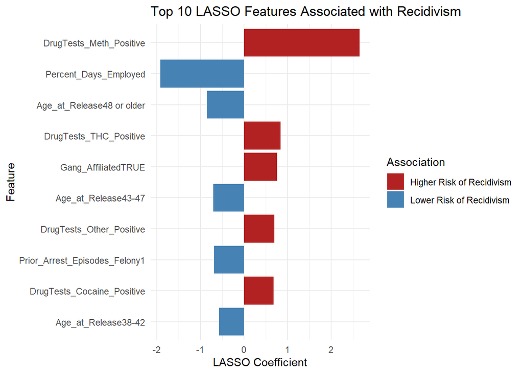

```r
# Get top 10 features by absolute value of coefficient (excluding intercept)
top10_lasso <- lasso_coef_df %>%
  arrange(desc(abs(coefficient))) %>%
  slice(1:10) %>%
  mutate(risk_direction = ifelse(coefficient > 0,
                                 "Higher Risk of Recidivism",
                                 "Lower Risk of Recidivism"))

# Plot
ggplot(top10_lasso, aes(x = reorder(feature, abs(coefficient)), y = coefficient, fill = risk_direction)) +
  geom_bar(stat = "identity") +
  coord_flip() +
  scale_fill_manual(values = c("Higher Risk of Recidivism" = "firebrick",
                               "Lower Risk of Recidivism" = "steelblue")) +
  labs(title = "Top 10 LASSO Features Associated with Recidivism",
       x = "Feature", y = "LASSO Coefficient", fill = "Association") +
  theme_minimal()
```

The larger the absolute value of a coefficient, the more influence that feature has on the predicted probability of the outcome (e.g., recidivism).

A positive coefficient increases the log-odds (i.e., is associated with a higher likelihood of recidivism).

A negative coefficient decreases the log-odds (i.e., is associated with a lower likelihood of recidivism).